# Week 2: Fitting Simple Models, Interpreting Samples from a Posterior

STAT 341, SP23

## New Case Study

```r
product_share <- haven::read_dta('https://colindavison.github.io/colin_davison_website/product_share.dta') |>
  mutate(n_product_patents = round(product_share * ind_claims),
         n_process_patents = round((1 - product_share) * ind_claims)) |>
  na.omit()

head(product_share)
```

```
## # A tibble: 6 × 5
##   patent_number product_share ind_claims n_product_patents n_process_patents
##   <chr>                 <dbl>      <dbl>             <dbl>             <dbl>
## 1 US3598122             1              1                 1                 0
## 2 US3646377             1              1                 1                 0
## 3 US3651418             1              1                 1                 0
## 4 US3671890             1              1                 1                 0
## 5 US3703718             1              5                 5                 0
## 6 US3708779             0.800          5                 4                 1
```

```r
total_product <- sum(~n_product_patents, data  = product_share)
total_process <- sum(~n_process_patents, data = product_share)

total_product
```

```
## [1] 2461788
```

```r
total_process
```

```
## [1] 452490
```

## Fit Model via Grid Approximation

Let $Prod$ be the event that a US patent filed by a manufacturing company is for a *product* rather than a *process.* We want to fit a Bayesian model to estimate $P(Prod)$.

```r
grid_patent_model <-
  tibble(p_grid = seq(from = 0, to = 1, length.out = 100000),      # define grid
         # prior  = 1, # define prior. But saying "prior = 1" is a shortcut for specifying a  uniform prior...what if we instead spell it out?
         prior = dunif(p_grid, min = 0, max = 1)
         ) |>                                       # define prior
  mutate(likelihood = dbinom(total_product,
                             size = total_product  + total_process,
                             prob = p_grid)) |>  # compute likelihood at each value in grid
  mutate(unstd_posterior = likelihood * prior) |>             # compute product of likelihood and prior
  mutate(posterior = unstd_posterior / sum(unstd_posterior))   # standardize the posterior, so it sums to 1


# to peek at the results table
glimpse(grid_patent_model)
```

```
## Rows: 100,000
## Columns: 5
## $ p_grid          <dbl> 0.0000000000, 0.0000100001, 0.0000200002, 0.0000300003…
## $ prior           <dbl> 1, 1, 1, 1, 1, 1, 1, 1, 1, 1, 1, 1, 1, 1, 1, 1, 1, 1, …
## $ likelihood      <dbl> 0, 0, 0, 0, 0, 0, 0, 0, 0, 0, 0, 0, 0, 0, 0, 0, 0, 0, …
## $ unstd_posterior <dbl> 0, 0, 0, 0, 0, 0, 0, 0, 0, 0, 0, 0, 0, 0, 0, 0, 0, 0, …
## $ posterior       <dbl> 0, 0, 0, 0, 0, 0, 0, 0, 0, 0, 0, 0, 0, 0, 0, 0, 0, 0, …
```

### Draw the posterior

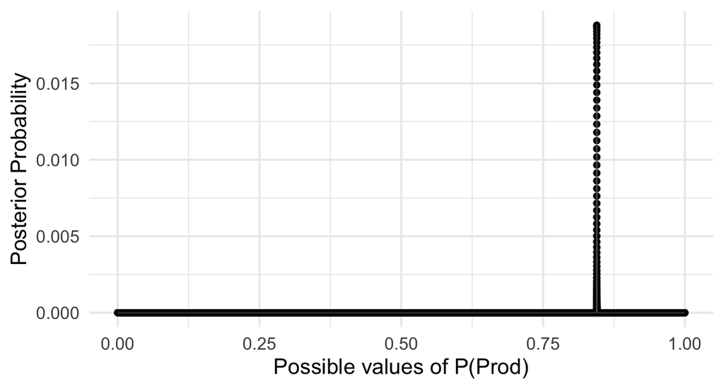

```r
grid_post_plot <- gf_point(posterior ~ p_grid,
                           data = grid_patent_model) |>
  # this is optional -- adds a line in addition to  the dots
  gf_line(color = 'grey44', alpha = 0.5) |>
  gf_labs(x = 'Possible values of P(Prod)',
          y = 'Posterior Probability')

grid_post_plot
```

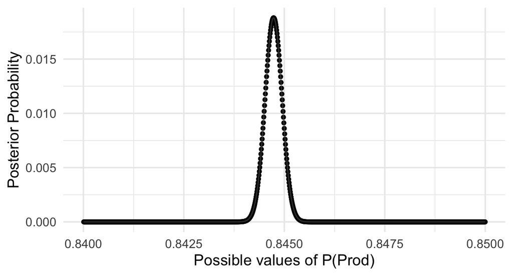

```r
# zooming in, since the posterior is so tall and skinny:
grid_post_plot |> gf_lims(x = c(0.84, 0.85))
```

## Fit Model via Quadratic Approximation

This is an alternate, generally more efficient way of fitting the same model.

```r
library(rethinking)

quap_patent_model <- quap(
  # entries to alist() are the model setup, in the abstract
  # (no numbers!)
  alist(
    Prod ~ dbinom(size = Prod + Proc, prob = p),  # binomial likelihood of getting "the data" (here: count of successes)
    p ~ dunif(0 , 1)        # **uniform** prior for the probability of success, "p"
  ),
  # here's where  the actual observed data come in:
  data = list(Prod = total_product, Proc = total_process)
)

# display a summary of quadratic approximation
precis(quap_patent_model)
```

```
##        mean           sd      5.5%     94.5%
## p 0.8447317 0.0002121397 0.8443926 0.8450707
```

## Other Priors

As you’ve read, a diffuse or uninformative prior is not always a good and honest choice. What other option do we have in this scenario?

### Uniform using `dunif()`

Saying the prior plausibility is 1 for all conjectured values of $p$ is the same as saying $p \sim Unif(min = 0, max = 1)$.

The uniform distribution says that all possible values between the stated `min` and `max` are equally likely. To draw a picture of this uniform prior:

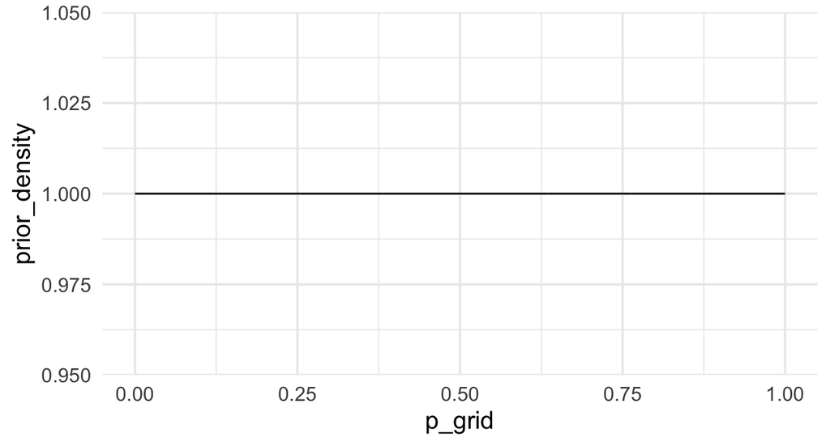

```r
my_unif_prior <- tibble(p_grid = seq(from = 0, to = 1, length.out = 1000),
                        prior_density =dunif(p_grid, min = 0, max = 1))
gf_line(prior_density ~ p_grid, data = my_unif_prior)
```

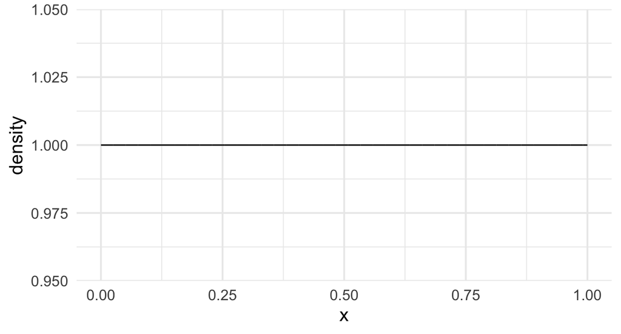

```r
# or:
gf_dist(dist = 'unif', min = 0, max = 1)
```

This is uninformative and may not *actually* accurately reflect prior knowledge. What alternatives do we have?

### Beta using `dbeta()`

Another distribution with support (possible conjecture values) between 0-1 is the **Beta distribution**. It has parameters `shape1` and `shape2` (also known as $\alpha$ and $\beta$ = alpha and beta, outside R). Both `shape1` and `shape2` must be real numbers greater than 0, and the mean of the distribution is $\frac{shape1}{shape1 + shape2}$.

(Practically: you can experiment with changing values of `shape1` and `shape2` to get the prior distribution you envision.) To plot this distribution in R:

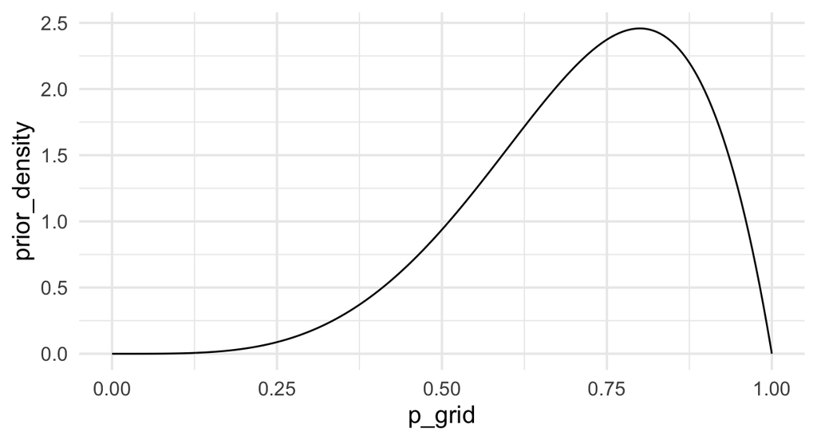

```r
my_beta_prior <- tibble(p_grid = seq(from = 0, to = 1, length.out = 1000),
                        prior_density = dbeta(p_grid, shape1 = 5, shape2 = 2))
gf_line(prior_density ~ p_grid, data = my_beta_prior)
```

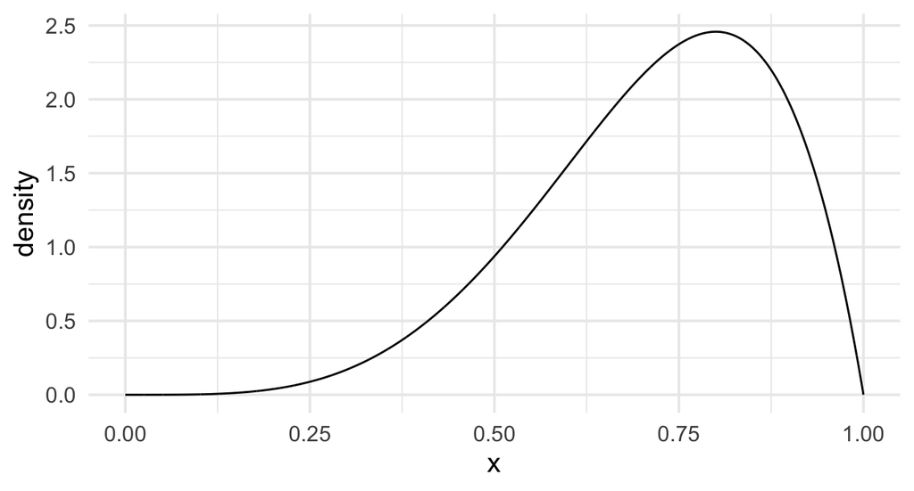

```r
# or:
gf_dist(dist = 'beta',  shape1 = 5, shape2 = 2)
```

### Your own (?)

You could manually assign a (relative) probability to every value of `p_grid` you want to consider. This is rare (but is shown in SR Chapter 2).

## Samples from Posterior

Some fitting methods don’t provide the posterior in a functional form (one probability or density for every conjectured value of the parameter $p$); they only provide a way of getting *samples* from the posterior. And often, working with a sample from the posterior is more intuitive and familiar anyway.

We can get a sample from the posterior after using grid approximation *or* `quap()` to fit a model…

### Posterior sample from grid-approximated model

```r
post_samp_size = 10000
# eliminate sampling variation: get the same exact samples each time you run/knit
# by setting the "seed" of the random number generator
# you can change the  3 to  an integer of your choice
set.seed(3)
grid_post_samp <- grid_patent_model |>
  slice_sample(n = post_samp_size,
               weight_by = 10000*posterior,
               replace = TRUE) |>
  # sort of optional - but to avoid confusion, keep ONLY the posterior
  select(p_grid) |>
  rename(p = p_grid)

# if you need the posterior samples p to be a vector instead of a variable inside a dataframe:
# grid_post_samp <- grid_post_samp$p
# or equivalently
# grid_post_samp <- pull(grid_post_samp, p)
```

### Posterior Sample from quadratic-approximated model

```r
set.seed(75)
quap_post_samp <- sample.qa.posterior(quap_patent_model,
                                      n = post_samp_size)
```

### Visualization

Options!

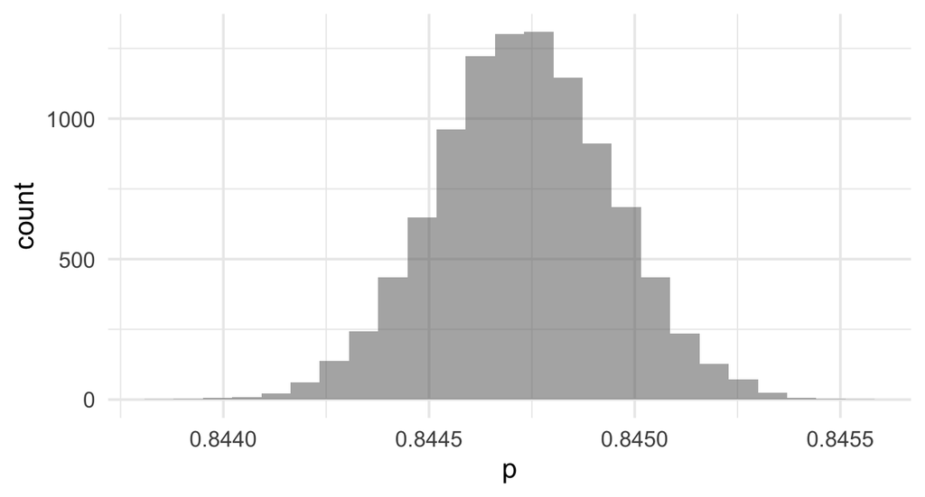

```r
gf_histogram(~p, data = quap_post_samp)
```

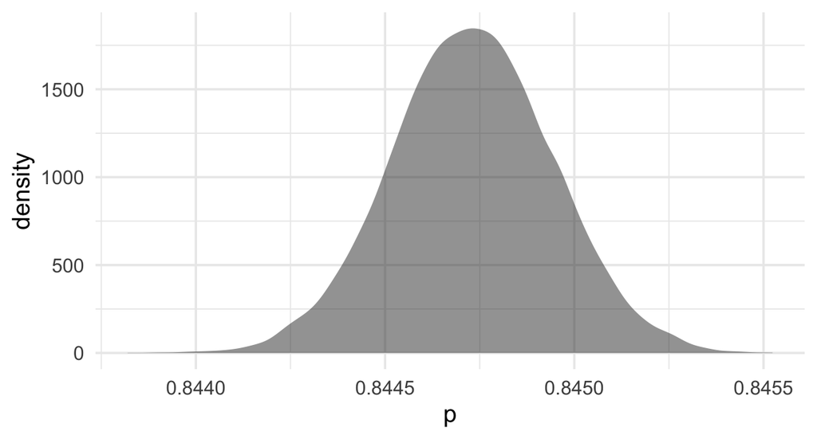

```r
gf_density(~p, data = quap_post_samp)
```

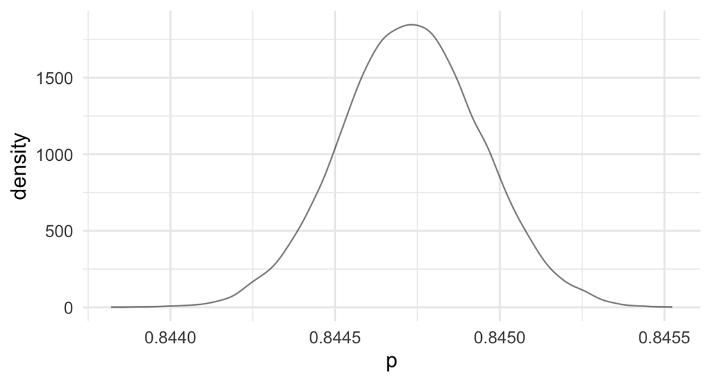

```r
gf_dens(~p, data = quap_post_samp)
```

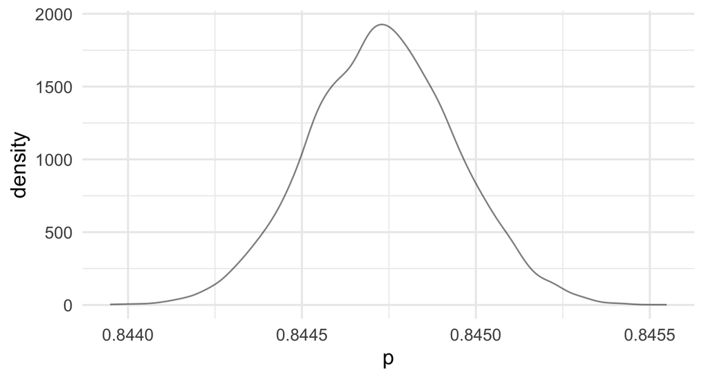

```r
gf_dens(~p, data = grid_post_samp)
```

```r
# gf_boxplot(~p, data = quap_post_samp) # probably a poor choice - why?
```

### Probabilities

To find probabilities based on the posterior, we just have to find the *proportion* of the *posterior samples* that meet the condition we are interested in.

For example, what is $P(p > 0.5)$ in this example? $P(p > 0.845)$? $P(0.8445 < p < 0.85)$?

We need to count the number of times the sampled $p$ meets our condition, then divide by the total sample size. There are lots of ways to do it in R; here’s one. Function `n()` counts the total number of cases (rows) under consideration and only works inside functions like `mutate()` and `summarize()`.

```r
quap_post_samp |>
  mutate(above0p5 = p > 0.5,
         above0p845 = p > 0.845,
         btw = p > 0.8445 & p < 0.85) |>
  summarise(prob1 = sum(above0p5) / n(),
            prob2 = sum(above0p845 / n()),
            prob3 = sum(btw) / n())
```

```
##   prob1  prob2  prob3
## 1     1 0.1023 0.8632
```

### Numerical Summary Stats

#### Resist being bullied into thinking you “need to report one number”. The graphical presentations are great! Who needs one number to report!

(But one could do so…)

```r
# mean
mean(~p, data = quap_post_samp)
```

```
## [1] 0.8447298
```

```r
# median
median(~p, data = quap_post_samp)
```

```
## [1] 0.8447296
```

```r
# mode ("Maximum a Posteriori" or MAP)
chainmode(quap_post_samp$p)
```

```
## [1] 0.8447327
```

In addition to the one-number *point estimates* above, we can also find *interval estimates* to try to give some idea of the amount of uncertainty we have about the most likely values of $p$.

For example:

- A **credible interval** also known as **compatibility interval**. This is the Bayesian sort-of-equivalent of a frequentist confidence interval, except unlike a CI, it literally gives an interval that has a 95% (or other chosen percent) *probability* of containing the true parameter value. The compatibility interval is the boundaries of the middle 0.95 proportion of the area-under-the-curve of the posterior
- The **Highest Posterior Density Interval** or **HPDI** gives the boundaries of the 0.95 proportion of the posterior that has the highest densities. (Or, we can use any other proportion instead of 0.95).

Compute them like so (if someone really, really makes you compute one; else why not just show one of the visualizations?):

```r
# credible interval
cdata(~p, data  = quap_post_samp, p = 0.95)
```

```
##          lower     upper central.p
## 2.5% 0.8443092 0.8451479      0.95
```

```r
# HPDI
# note this function uses the syntax: datasetname$variablename
# and not: ~variablename, data = datasetname
HPDI(quap_post_samp$p, prob  = 0.95)
```

```
##     |0.95     0.95|
## 0.8443032 0.8451387
```